# R Notebook

```r
library(ggplot2)
```

#### Functions

The following function is the function which will be used to get the mode of the data

```r
mymode <- function(x){
  xtable <- table(x)
  idx <- xtable == max(xtable)
  names(xtable)[idx]
}
```

Read in the data from the csv file

```r
churn_data <- read.csv("./eurocomPHONEchurners.csv")
```

Display the data

```r
churn_data
```

| CUST_ID | AREA_CODE | MINUTES_CURR_MONTH | MINUTES_PREV_MONTH | MINUTES_3MONTHS_AGO | CUST_MOS | LONGDIST_FLAG | CALLWAITING_FLAG | NUM_LINES | VOICEMAIL_FLAG | MOBILE_PLAN | CONVERGENT_BILLING | GENDER | INCOME | PHONE_PLAN | EDUCATION | TOT_MINUTES_USAGE | CHURNER |
| --- | --- | --- | --- | --- | --- | --- | --- | --- | --- | --- | --- | --- | --- | --- | --- | --- | --- |
| 129 | 45987 | 60 | 456 | 398 | 13 | 0 | 1 | 1 | 1 | 0 | Yes | M | 88000 | International | Masters | 914 | yes |
| 130 | 15563 | 2 | 0 | 4 | 4 | 0 | 0 | 1 | 0 | 0 | Yes | M | 53000 | International | Bachelors | 6 | no |
| 131 | 10040 | 2 | 0 | 0 | 1 | 0 | 0 | 1 | 1 | 0 | No | F | 29000 | National | High School | 0 | no |
| 132 | 21750 | 678 | 1222 | 598 | 30 | 1 | 1 | 2 | 0 | 1 | Yes | M | 46000 | International | High School | 2498 | yes |
| 133 | 55166 | 110 | 98 | 56 | 15 | 1 | 0 | 1 | 1 | 0 | No | M | 98000 | Promo_plan | High School | 264 | no |
| 134 | 36785 | 97 | 56 | 97 | 8 | 0 | 0 | 1 | 0 | 1 | No | M | 125000 | National |  | 250 | no |
| 135 | 45987 | 45 | 23 | 66 | 44 | 0 | 0 | 1 | 0 | 0 | No | F | 91000 | International | PhD | 134 | no |
| 147 | 15563 | 105 | 15 | 99 | 11 | 0 | 0 | 2 | 1 | 0 | No | F | 51000 | International | Bachelors | 219 | no |
| 137 | 10040 | 1 | 2 | 0 | 2 | 0 | 0 | 1 | 0 | 0 | Yes | F | 17000 | National | Bachelors | 0 | no |
| 138 | 21750 | 5 | 15 | 75 | 6 | 1 | 0 | 1 | 1 | 0 | No | F | 39000 | International |  | 95 | no |

[output cut: 990 more lines]

First thing to do is to print out the data summary.

```r
summary(churn_data)
```

```
    CUST_ID         AREA_CODE     MINUTES_CURR_MONTH MINUTES_PREV_MONTH MINUTES_3MONTHS_AGO    CUST_MOS     LONGDIST_FLAG    CALLWAITING_FLAG   NUM_LINES
 Min.   :   1.0   Min.   :10040   Min.   :    1.0    Min.   :    0.0    Min.   :    0       Min.   : 1.00   Min.   :0.0000   Min.   :0.0000   Min.   :1.000
 1st Qu.: 517.5   1st Qu.:15563   1st Qu.:   33.0    1st Qu.:   15.0    1st Qu.:   29       1st Qu.: 6.00   1st Qu.:0.0000   1st Qu.:0.0000   1st Qu.:1.000
 Median :1035.0   Median :21750   Median :  105.0    Median :   98.0    Median :   97       Median :11.00   Median :1.0000   Median :0.0000   Median :1.000
 Mean   :1035.1   Mean   :29816   Mean   :  747.7    Mean   :  863.9    Mean   :  453       Mean   :16.05   Mean   :0.5649   Mean   :0.4346   Mean   :1.391
 3rd Qu.:1552.5   3rd Qu.:45987   3rd Qu.:  555.0    3rd Qu.:  444.0    3rd Qu.:  598       3rd Qu.:26.00   3rd Qu.:1.0000   3rd Qu.:1.0000   3rd Qu.:2.000
 Max.   :2070.0   Max.   :55166   Max.   :14000.0    Max.   :16754.0    Max.   :12456       Max.   :50.00   Max.   :1.0000   Max.   :1.0000   Max.   :3.000
                                                                        NA's   :3           NA's   :3
 VOICEMAIL_FLAG    MOBILE_PLAN     CONVERGENT_BILLING GENDER       INCOME               PHONE_PLAN          EDUCATION   TOT_MINUTES_USAGE CHURNER
 Min.   :0.0000   Min.   :0.0000   No :1241           F: 731   Min.   : 17000                :   4               :  8   Min.   :    0     no :1021
 1st Qu.:0.0000   1st Qu.:0.0000   Yes: 830           M:1340   1st Qu.: 46000   Euro-Zone    :  59   Bachelors   :400   1st Qu.:  116     yes:1050
 Median :1.0000   Median :0.0000                               Median : 75000   International:1067   High School :  3   Median :  264
 Mean   :0.5654   Mean   :0.3477                               Mean   : 85784   National     : 671   Masters     :330   Mean   : 2040
 3rd Qu.:1.0000   3rd Qu.:1.0000                               3rd Qu.: 98000   Promo_plan   : 270   PhD         :410   3rd Qu.: 1677
 Max.   :1.0000   Max.   :1.0000                               Max.   :320000                        Post Primary:829   Max.   :36237
                                                                                                     Primary     : 91   NA's   :4
```

### Identify null values

The summary data can be used to identify the columns which contain null values.

The columns with null values are:

- MINUTES_3MONTHS_AGO (3 records)
- CUST_MOS (3 records)
- TOT_MINUTES_USAGE (4 records)
- PHONE_PLAN (4 records)
- EDUCATION (8 records)

##### Addressing the issues of the missing values.

For the numeric values they will be replaced with median value for the columns

**MINUTES_3MONTHS_AGO**

```r
median(churn_data$MINUTES_3MONTHS_AGO, na.rm = TRUE)
```

```
[1] 97
```

```r
MINUTES_3MONTHS_AGO_median <- median(churn_data$MINUTES_3MONTHS_AGO, na.rm = TRUE)
```

```r
churn_data$MINUTES_3MONTHS_AGO[is.na(churn_data$MINUTES_3MONTHS_AGO)] <- MINUTES_3MONTHS_AGO_median
```

**CUST_MOS**

```r
median(churn_data$CUST_MOS, na.rm = TRUE)
```

```
[1] 11
```

```r
CUST_MOS_median <- median(churn_data$CUST_MOS, na.rm = TRUE)
```

```r
churn_data$CUST_MOS[is.na(churn_data$CUST_MOS)] <- CUST_MOS_median
```

**TOT_MINUTES_USAGE**

```r
median(churn_data$TOT_MINUTES_USAGE, na.rm = TRUE)
```

```
[1] 264
```

```r
TOT_MINUTES_USAGE_median <- median(churn_data$TOT_MINUTES_USAGE, na.rm = TRUE)
```

```r
churn_data$TOT_MINUTES_USAGE[is.na(churn_data$TOT_MINUTES_USAGE)] <- TOT_MINUTES_USAGE_median
```

**PHONE_PLAN**

The first thing to do was to ceate a data frame which is comprised of the gender and phone plan

```r
  phone_plan_gender_subset <- data.frame(churn_data$PHONE_PLAN, churn_data$GENDER)
```

```r
  phone_plan_gender_subset[1:10,]
```

|  | churn_data.PHONE_PLAN | churn_data.GENDER |
| --- | --- | --- |
| 1 | International | M |
| 2 | International | M |
| 3 | National | F |
| 4 | International | M |
| 5 | Promo_plan | M |
| 6 | National | M |
| 7 | International | F |
| 8 | International | F |
| 9 | National | F |
| 10 | International | F |

The data frame is then filtered again so it just contains data for record for male records

```r
  phone_plan_male_subset <- phone_plan_gender_subset[phone_plan_gender_subset$churn_data.GENDER == 'M', 1]
```

```r
  phone_plan_male_subset[1:10]
```

```
 [1] International International International Promo_plan    National      National      International National      National      International
Levels:  Euro-Zone International National Promo_plan
```

The mode of the phone plan is stored formale records

```r
  print(phone_plan_male_mode <- mymode(phone_plan_male_subset))
```

```
[1] "International"
```

The data frame is then filtered again so it just contains data for record for female records

```r
  phone_plan_female_subset <- phone_plan_gender_subset[phone_plan_gender_subset$churn_data.GENDER == 'F', 1]
```

```r
  phone_plan_female_subset[1:10]
```

```
 [1] National      International International National      International International National      International National      International
Levels:  Euro-Zone International National Promo_plan
```

```r
  print(phone_plan_female_mode <- mymode(phone_plan_female_subset))
```

```
[1] "International"
```

We then find the indexes of the phone plan records with empty values

```r
  no_phone_plans <- which(churn_data$PHONE_PLAN == "")
```

```r
  churn_data[no_phone_plans,]
```

|  | CUST_ID | AREA_CODE | MINUTES_CURR_MONTH | MINUTES_PREV_MONTH | MINUTES_3MONTHS_AGO | CUST_MOS | LONGDIST_FLAG | CALLWAITING_FLAG | NUM_LINES | VOICEMAIL_FLAG | MOBILE_PLAN | CONVERGENT_BILLING | GENDER | INCOME | PHONE_PLAN | EDUCATION | TOT_MINUTES_USAGE | CHURNER |
| --- | --- | --- | --- | --- | --- | --- | --- | --- | --- | --- | --- | --- | --- | --- | --- | --- | --- | --- |
| 673 | 352 | 36785 | 6000 | 7899 | 630 | 36 | 0 | 0 | 2 | 1 | 0 | Yes | M | 145000 |  | Post Primary | 14529 | yes |
| 979 | 914 | 21750 | 7543 | 16754 | 598 | 30 | 1 | 1 | 2 | 0 | 1 | Yes | M | 46000 |  | Post Primary | 24895 | yes |
| 1191 | 1190 | 21750 | 12000 | 8000 | 598 | 30 | 1 | 1 | 2 | 0 | 1 | Yes | M | 46000 |  | Post Primary | 20598 | yes |
| 1465 | 1656 | 21750 | 5000 | 7000 | 75 | 6 | 1 | 0 | 1 | 1 | 0 | No | F | 39000 |  | Post Primary | 264 | no |

```r
for (index in no_phone_plans)
{
  if (churn_data$GENDER[index] == 'M')
  {
    churn_data$PHONE_PLAN[index] <- phone_plan_male_mode
  }
  else
  {
    churn_data$PHONE_PLAN[index] <- phone_plan_female_mode
  }
}
```

```r
  churn_data$PHONE_PLAN[no_phone_plans]
```

```
[1] International International International International
Levels:  Euro-Zone International National Promo_plan
```

**EDUCATION** The first thing to do was to ceate a data frame which is comprised of the gender and education

```r
  education_gender_subset <- data.frame(churn_data$EDUCATION, churn_data$GENDER)
```

```r
  education_gender_subset[1:10,]
```

|  | churn_data.EDUCATION | churn_data.GENDER |
| --- | --- | --- |
| 1 | Masters | M |
| 2 | Bachelors | M |
| 3 | High School | F |
| 4 | High School | M |
| 5 | High School | M |
| 6 |  | M |
| 7 | PhD | F |
| 8 | Bachelors | F |
| 9 | Bachelors | F |
| 10 |  | F |

The data frame is then filtered again so it just contains data for record for male records

```r
  no_education_male_subset <- education_gender_subset[education_gender_subset$churn_data.GENDER == 'M', 1]
```

```r
  no_education_male_subset[1:10]
```

```
 [1] Masters     Bachelors   High School High School             Primary     PhD         PhD         Masters     Masters
Levels:  Bachelors High School Masters PhD Post Primary Primary
```

```r
  no_education_male_mode <- mymode(no_education_male_subset)
```

```r
  no_education_male_mode
```

```
[1] "Post Primary"
```

The data frame is then filtered again so it just contains data for record for female records

```r
  no_education_female_subset <- education_gender_subset[education_gender_subset$churn_data.GENDER == 'F', 1]
```

```r
  no_education_female_mode <- mymode(no_education_female_subset)
```

```r
  no_education_female_mode
```

```
[1] "Bachelors"
```

```r
  no_education <- which(churn_data$EDUCATION == "")
```

```r
  churn_data[no_education,]
```

|  | CUST_ID | AREA_CODE | MINUTES_CURR_MONTH | MINUTES_PREV_MONTH | MINUTES_3MONTHS_AGO | CUST_MOS | LONGDIST_FLAG | CALLWAITING_FLAG | NUM_LINES | VOICEMAIL_FLAG | MOBILE_PLAN | CONVERGENT_BILLING | GENDER | INCOME | PHONE_PLAN | EDUCATION | TOT_MINUTES_USAGE | CHURNER |
| --- | --- | --- | --- | --- | --- | --- | --- | --- | --- | --- | --- | --- | --- | --- | --- | --- | --- | --- |
| 6 | 134 | 36785 | 97 | 56 | 97 | 8 | 0 | 0 | 1 | 0 | 1 | No | M | 125000 | National |  | 250 | no |
| 10 | 138 | 21750 | 5 | 15 | 75 | 6 | 1 | 0 | 1 | 1 | 0 | No | F | 39000 | International |  | 95 | no |
| 109 | 237 | 36785 | 398 | 144 | 630 | 36 | 0 | 0 | 2 | 1 | 0 | No | M | 145000 | National |  | 1172 | no |
| 233 | 104 | 55166 | 344 | 232 | 455 | 11 | 1 | 1 | 2 | 1 | 1 | Yes | M | 75000 | Promo_plan |  | 1031 | no |
| 283 | 282 | 55166 | 550 | 55 | 500 | 17 | 1 | 1 | 1 | 0 | 0 | No | M | 320000 | Promo_plan |  | 1105 | no |
| 339 | 466 | 55166 | 550 | 100 | 500 | 17 | 1 | 1 | 1 | 0 | 0 | No | M | 320000 | Promo_plan |  | 1150 | no |
| 1366 | 228 | 15563 | 53 | 34 | 29 | 50 | 1 | 1 | 1 | 0 | 0 | No | F | 48000 | International |  | 116 | yes |
| 1389 | 44 | 15563 | 53 | 34 | 29 | 50 | 1 | 1 | 1 | 0 | 0 | No | F | 48000 | International |  | 116 | yes |

```r
for (index in no_education)
{
  if (churn_data$GENDER[index] == 'M')
  {
    churn_data$EDUCATION[index] <- no_education_male_mode
  }
  else
  {
    churn_data$EDUCATION[index] <- no_education_female_mode
  }
}
```

```r
churn_data$EDUCATION[no_education]
```

```
[1] Post Primary Bachelors    Post Primary Post Primary Post Primary Post Primary Bachelors    Bachelors
Levels:  Bachelors High School Masters PhD Post Primary Primary
```

```r
summary(churn_data)
```

```
    CUST_ID         AREA_CODE     MINUTES_CURR_MONTH MINUTES_PREV_MONTH MINUTES_3MONTHS_AGO    CUST_MOS     LONGDIST_FLAG    CALLWAITING_FLAG   NUM_LINES
 Min.   :   1.0   Min.   :10040   Min.   :    1.0    Min.   :    0.0    Min.   :    0.0     Min.   : 1.00   Min.   :0.0000   Min.   :0.0000   Min.   :1.000
 1st Qu.: 517.5   1st Qu.:15563   1st Qu.:   33.0    1st Qu.:   15.0    1st Qu.:   29.0     1st Qu.: 6.00   1st Qu.:0.0000   1st Qu.:0.0000   1st Qu.:1.000
 Median :1035.0   Median :21750   Median :  105.0    Median :   98.0    Median :   97.0     Median :11.00   Median :1.0000   Median :0.0000   Median :1.000
 Mean   :1035.1   Mean   :29816   Mean   :  747.7    Mean   :  863.9    Mean   :  452.5     Mean   :16.05   Mean   :0.5649   Mean   :0.4346   Mean   :1.391
 3rd Qu.:1552.5   3rd Qu.:45987   3rd Qu.:  555.0    3rd Qu.:  444.0    3rd Qu.:  598.0     3rd Qu.:26.00   3rd Qu.:1.0000   3rd Qu.:1.0000   3rd Qu.:2.000
 Max.   :2070.0   Max.   :55166   Max.   :14000.0    Max.   :16754.0    Max.   :12456.0     Max.   :50.00   Max.   :1.0000   Max.   :1.0000   Max.   :3.000

 VOICEMAIL_FLAG    MOBILE_PLAN     CONVERGENT_BILLING GENDER       INCOME               PHONE_PLAN          EDUCATION   TOT_MINUTES_USAGE CHURNER
 Min.   :0.0000   Min.   :0.0000   No :1241           F: 731   Min.   : 17000                :   0               :  0   Min.   :    0     no :1021
 1st Qu.:0.0000   1st Qu.:0.0000   Yes: 830           M:1340   1st Qu.: 46000   Euro-Zone    :  59   Bachelors   :403   1st Qu.:  116     yes:1050
 Median :1.0000   Median :0.0000                               Median : 75000   International:1071   High School :  3   Median :  264
 Mean   :0.5654   Mean   :0.3477                               Mean   : 85784   National     : 671   Masters     :330   Mean   : 2036
 3rd Qu.:1.0000   3rd Qu.:1.0000                               3rd Qu.: 98000   Promo_plan   : 270   PhD         :410   3rd Qu.: 1677
 Max.   :1.0000   Max.   :1.0000                               Max.   :320000                        Post Primary:834   Max.   :36237
                                                                                                     Primary     : 91
```

```r
churn_data$INCOME <- cut(churn_data$INCOME, breaks=c(0,38000,88000,Inf), right = FALSE, labels=c("low income","medium income","high income"))
```

```r
churn_data[1:10,]
```

|  | CUST_ID | AREA_CODE | MINUTES_CURR_MONTH | MINUTES_PREV_MONTH | MINUTES_3MONTHS_AGO | CUST_MOS | LONGDIST_FLAG | CALLWAITING_FLAG | NUM_LINES | VOICEMAIL_FLAG | MOBILE_PLAN | CONVERGENT_BILLING | GENDER | INCOME | PHONE_PLAN | EDUCATION | TOT_MINUTES_USAGE | CHURNER |
| --- | --- | --- | --- | --- | --- | --- | --- | --- | --- | --- | --- | --- | --- | --- | --- | --- | --- | --- |
| 1 | 129 | 45987 | 60 | 456 | 398 | 13 | 0 | 1 | 1 | 1 | 0 | Yes | M | high income | International | Masters | 914 | yes |
| 2 | 130 | 15563 | 2 | 0 | 4 | 4 | 0 | 0 | 1 | 0 | 0 | Yes | M | medium income | International | Bachelors | 6 | no |
| 3 | 131 | 10040 | 2 | 0 | 0 | 1 | 0 | 0 | 1 | 1 | 0 | No | F | low income | National | High School | 0 | no |
| 4 | 132 | 21750 | 678 | 1222 | 598 | 30 | 1 | 1 | 2 | 0 | 1 | Yes | M | medium income | International | High School | 2498 | yes |
| 5 | 133 | 55166 | 110 | 98 | 56 | 15 | 1 | 0 | 1 | 1 | 0 | No | M | high income | Promo_plan | High School | 264 | no |
| 6 | 134 | 36785 | 97 | 56 | 97 | 8 | 0 | 0 | 1 | 0 | 1 | No | M | high income | National | Post Primary | 250 | no |
| 7 | 135 | 45987 | 45 | 23 | 66 | 44 | 0 | 0 | 1 | 0 | 0 | No | F | high income | International | PhD | 134 | no |
| 8 | 147 | 15563 | 105 | 15 | 99 | 11 | 0 | 0 | 2 | 1 | 0 | No | F | medium income | International | Bachelors | 219 | no |
| 9 | 137 | 10040 | 1 | 2 | 0 | 2 | 0 | 0 | 1 | 0 | 0 | Yes | F | low income | National | Bachelors | 0 | no |
| 10 | 138 | 21750 | 5 | 15 | 75 | 6 | 1 | 0 | 1 | 1 | 0 | No | F | medium income | International | Bachelors | 95 | no |

## Predictor Information

Unique Account Number that identifies an account holder

| Predictor | CUST_ID |
| --- | --- |
| attribute type | Nominal ` |
| Max | 2070 |
| Min | 1 |

Geographical area account holder resides

| Predictor | AREA_CODE |
| --- | --- |
| attribute type | Nominal |
| %Missing Values | 0% |
| Mode | 10040 |

```r
#ggplot(data=data.frame(table(churn_data$CHURNER, churn_data$AREA_CODE)) ,aes(x=Var2, y=Freq, fill=Var1)) + geom_histogram()
```

Phone Minutes currently for current months (to the time the data was extracted)

| Predictor | MINUTES_CURR_MONTH |
| --- | --- |
| attribute type | Numeric |
| %Missing Values | 0% |
| Max | 14000 |
| Min | 1 |
| Mean | 747.7315307 |
| Mode | 2 |
| median | 105 |
| Standard deviation | 2017.1348476 |

```
Ignoring unknown parameters: binwidth, bins, pad
```

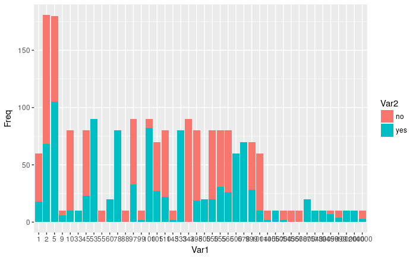

```r
ggplot(data=data.frame(table(churn_data$MINUTES_CURR_MONTH, churn_data$CHURNER)) ,aes(x=Var1, y=Freq, fill=Var2)) + geom_histogram(stat ="identity")
```

[figure not shown]

```r
hist_cut <- ggplot(data.frame(churn_data$MINUTES_CURR_MONTH, churn_data$CHURNER), aes(x=churn_data.MINUTES_CURR_MONTH, fill=churn_data.CHURNER))
hist_cut
```

```
Ignoring unknown parameters: bin
```

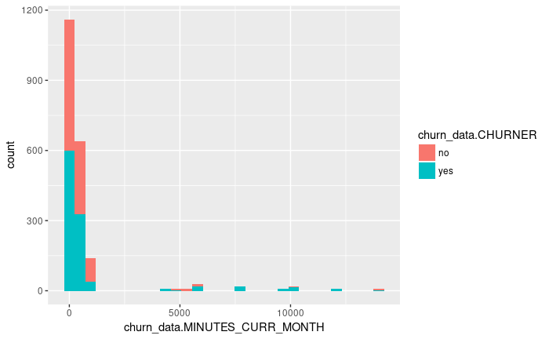

```r
hist_cut + geom_histogram(bin = 1) # defaults to stacking
```

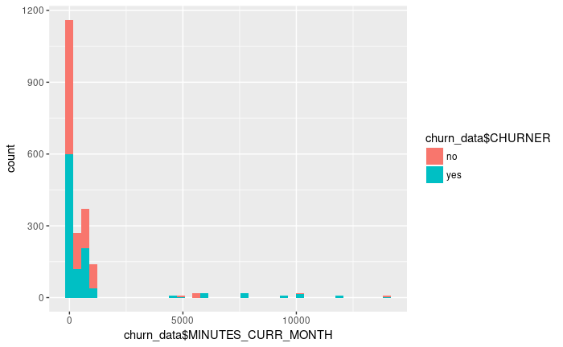

```r
ggplot(data=churn_data ,aes(x=churn_data$MINUTES_CURR_MONTH, group=churn_data$CHURNER, fill=churn_data$CHURNER)) + geom_histogram(binwidth = 350)
```

[figure not shown]

```r
hist(churn_data$MINUTES_CURR_MONTH,
     main="Histogram for Minutes In Current Month",
     labels=T,
     xlab="Minutes",
     ylab="Customers",
     border="black",
     ylim=c(0,nrow(churn_data) + 10),
     col=c("light blue","cyan"),
     breaks=10)
legend("topright",
  c("Didn't churn","Churned"),
  fill = c("light blue","cyan")
)
```

Phone Minutes used in the previous month

| Predictor | MINUTES_PREV_MONTH |
| --- | --- |
| attribute type | Numerical |
| %Missing Values |  |
| Max | 16754 |
| Min | 0 |
| Mean | 863.9014969 |
| Mode | 0 |
| median | 98 |

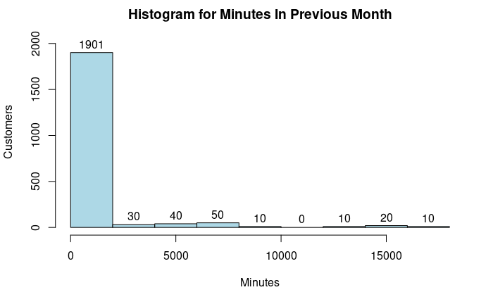

```r
hist(churn_data$MINUTES_PREV_MONTH,
     main="Histogram for Minutes In Previous Month",
     labels=T,
     xlab="Minutes",
     ylab="Customers",
     border="black",
     ylim=c(0,nrow(churn_data) + 10),
     col=c("light blue"),
     breaks=10)
```

#### Phone Minutes used in the 3 month PREVIOUS

[output not shown]

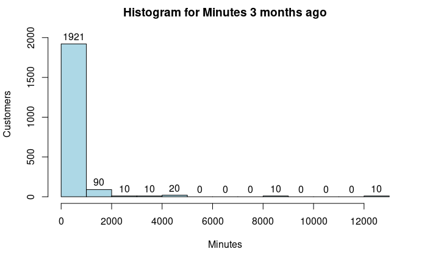

```r
hist(churn_data$MINUTES_3MONTHS_AGO,
     main="Histogram for Minutes 3 months ago",
     labels=T,
     xlab="Minutes",
     ylab="Customers",
     border="black",
     ylim=c(0,nrow(churn_data) + 10),
     col=c("light blue"),
     breaks=10)
```

##### The number of continuous months the Customer is with the provider

Predictor

CUST_MOS

attribute type

Numerical

%Missing Values

```
                0
```

Max

50

Min

1

Mean

16.0473201

Mode

11

median

11

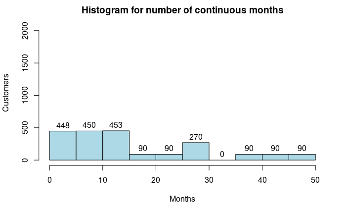

```r
hist(churn_data$CUST_MOS,
     main="Histogram for number of continuous months",
     labels=T,
     xlab="Months",
     ylab="Customers",
     border="black",
     ylim=c(0,nrow(churn_data) + 10),
     col=c("light blue"),
     breaks=10)
```

##### Whether has signed up for the off-peak long distance call package

Predictor

LONGDIST_FLAG

attribute type

Nominal

%Missing Values

```
                0
```

Mode

1

```r
table(churn_data$LONGDIST_FLAG, churn_data$CHURNER)
```

```
     no yes
  0 429 472
  1 592 578
```

[figure not shown]

```r
barplot(table(churn_data$LONGDIST_FLAG, churn_data$CHURNER),
        main="Main Title ",
        xlab="Off-peak long distance call package",
        ylab="Customers",
        border="black",
        ylim=c(0,nrow(churn_data) + 10),
        col=c("light blue", "cyan"),
        names.arg=c("No", "Yes")
        )
legend("topright",
  c("Didn't churn","Churned"),
  fill = c("light blue","cyan")
)
```

```
Ignoring unknown parameters: binwidth, bins, pad
```

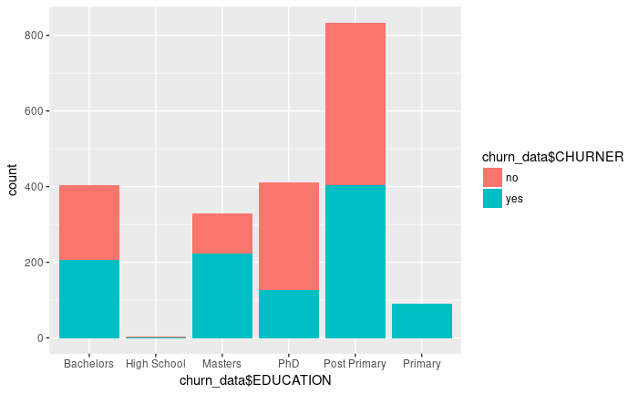

```r
ggplot(data=churn_data ,aes(x=churn_data$EDUCATION, group=churn_data$CHURNER, fill=churn_data$CHURNER)) + geom_histogram(stat="count")
```

```
Ignoring unknown parameters: binwidth, bins, pad
```

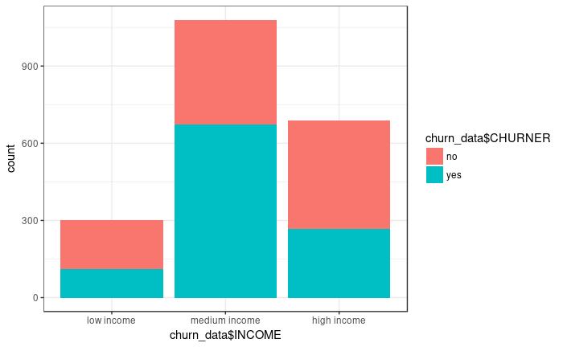

```r
ggplot(data=churn_data ,aes(x=churn_data$INCOME, group=churn_data$CHURNER, fill=churn_data$CHURNER)) + geom_histogram(stat="count") + theme_bw()
```

#### Whether the customer has call waiting

| Predictor | CALLWAITING_FLAG |
| --- | --- |
| attribute type | Nominal |
| %Missing Values | 0% |
| Mode | 0 |

#### The number of fixed lines the customer has leased.

| Predictor | NUM_LINES |
| --- | --- |
| attribute type | Numeric |
| %Missing Values | 0% |
| Max | 3 |
| Min | 1 |
| Mean | 1.3911154 |
| Mode | 1 |
| median | 1 |
| Standard deviation | 0.5702769 |

#### Whether the customer has voice mail

| Predictor | VOICEMAIL_FLAG |
| --- | --- |
| attribute type | Nominal |
| %Missing Values | 0% |
| Mode | 1 |

#### Has the customer signed up to the mobile phone plan

| Predictor | MOBILE_PLAN |
| --- | --- |
| attribute type | Nominal |
| %Missing Values | 0% |
| Mode | 0 |

#### All service charges consolidated onto one bill

| Predictor | CONVERGENT_BILLING |
| --- | --- |
| attribute type | Nominal |
| %Missing Values | 0% |
| Mode | No |

#### Account holder’s gender

| Predictor | GENDER |
| --- | --- |
| attribute type | Nominal |
| %Missing Values | 0% |
| Mode | M |

#### Account holder’s annual income (€)

| Predictor | INCOME |
| --- | --- |
| attribute type | Nominal |
| %Missing Values | 0% |
| Mode | medium income |

#### The phone plan the customer has signed up for national, euro-zone, international (outside Euro-zone) and promo_plan (signed up to the promotional plan)

| Predictor | PHONE_PLAN |
| --- | --- |
| attribute type | Nominal |
| %Missing Values | 0% |
| Mode | International |

#### Highest Level of education attainment the account holder has achieved

| Predictor | EDUCATION |
| --- | --- |
| attribute type | Nominal |
| %Missing Values | 0% |
| Mode | Post Primary |

#### The total number of minutes used to date

| Predictor | TOT_MINUTES_USAGE | Predictor | TOT_MINUTES_USAGE |
| --- | --- | --- | --- |
| attribute type | Numeric |  |  |
| %Missing Values | 0% |  |  |
| Max | 36237 |  |  |
| Min | 0 |  |  |
| Mean | 2036.1096089 |  |  |
| Mode | 0 |  |  |
| median | 264 |  |  |
| Standard deviation | 4882.9331552 |  |  |

[output not shown]